# Scenario summary of social distancing models

Detailing model parameters and impact of each example scenario

Caroline Colijn

Bo Wen

02/04/2020

*To download data export for all scenario documented here, go to the Data Summary and Download section.*

# Scenario Results

## Scenario 1: No Social Distancing

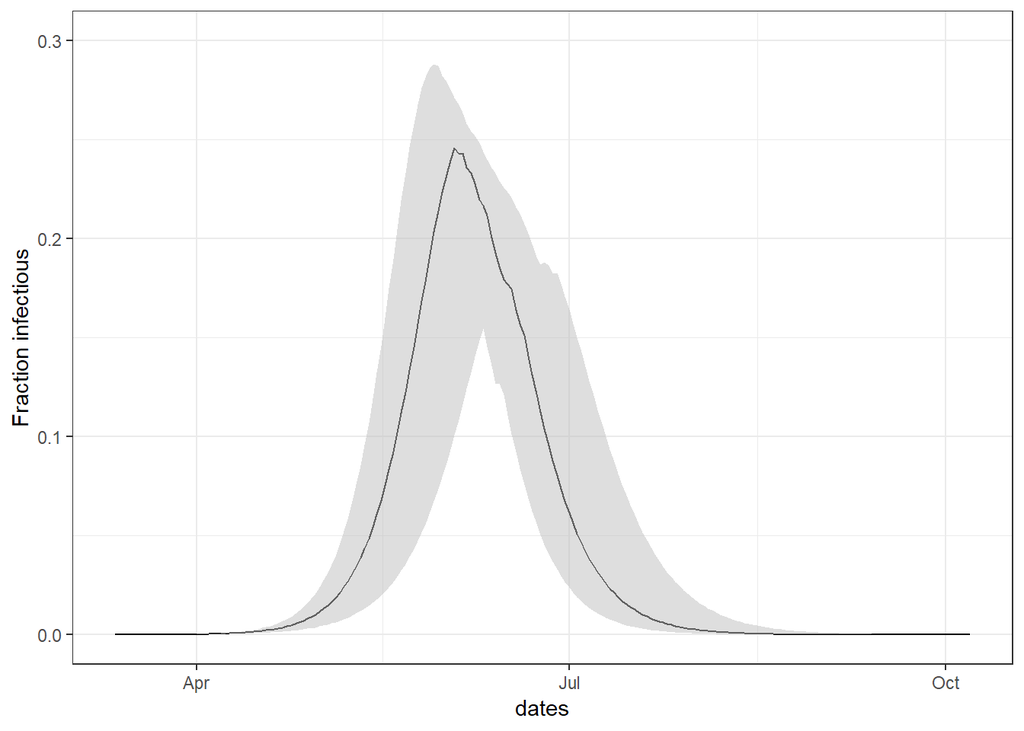

**Figure 1a**: Infections over time for no social distancing

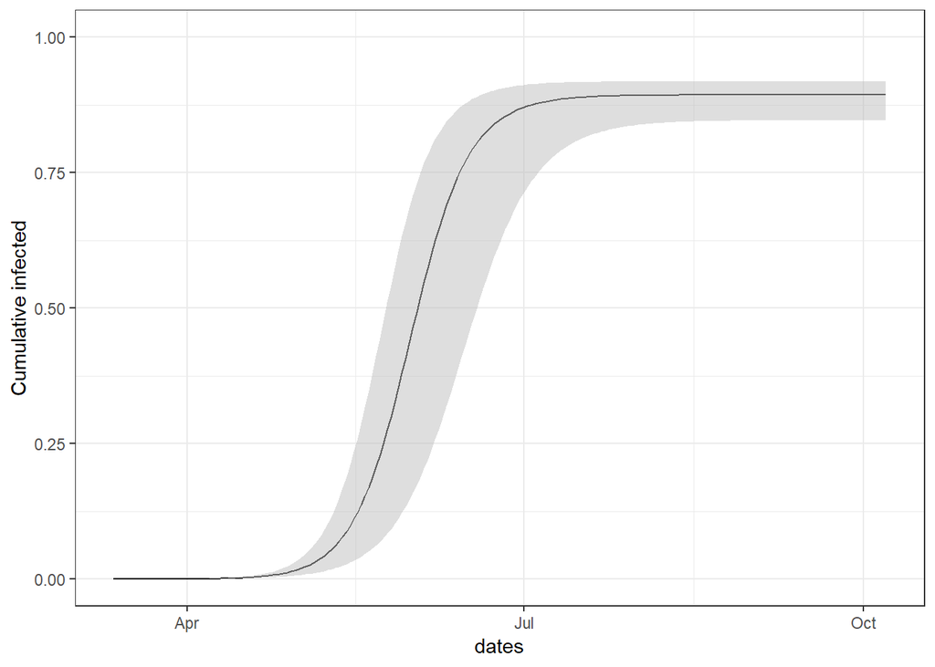

**Figure 1b**: Cumulative infections over time for no social distancing

## Scenario 2: Medium-scale Social Distancing

*Example calculation of contact factor $f$ for meidum-scale social distancing*

```r
hh=0.25; school=0.25*0.4; work=0.75*0.4; community=0.35; # portion contacts
f = hh*1 + school*0.9 + work*0.65 + community*0.75
f
```

```
## [1] 0.7975
```

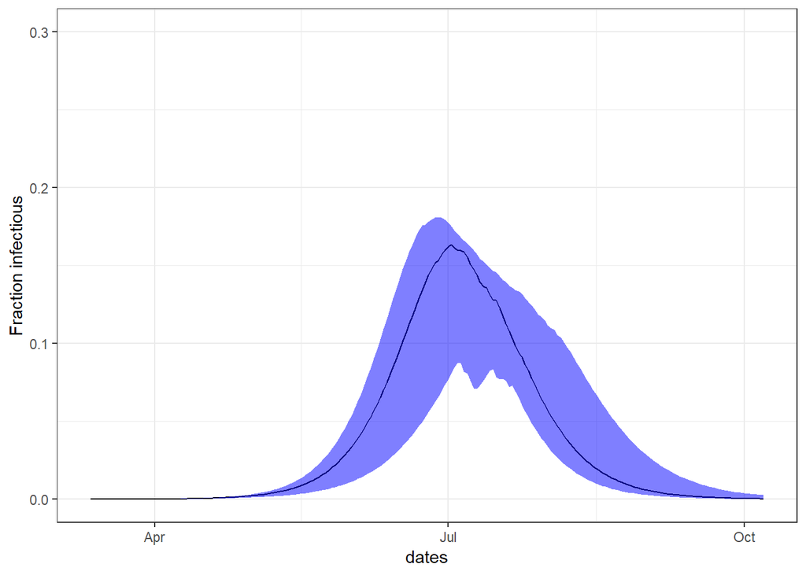

**Figure 2a**: Infections over time for medium social distancing

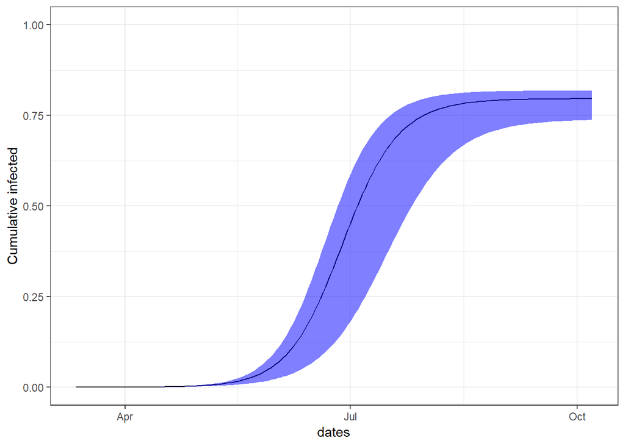

**Figure 2b**: Cumulative infections over time for medium social distancing

## Scenario 3: Strong Broad Social Distancing

Example calculation of contact factor $f$ for high-level social distancing

```r
hh=0.25; school=0.25*0.4; work=0.75*0.4; community=0.35; # portion contacts
f = hh*1.45 + school*0.1 + work*0.35 + community*0.35
f
```

```
## [1] 0.6
```

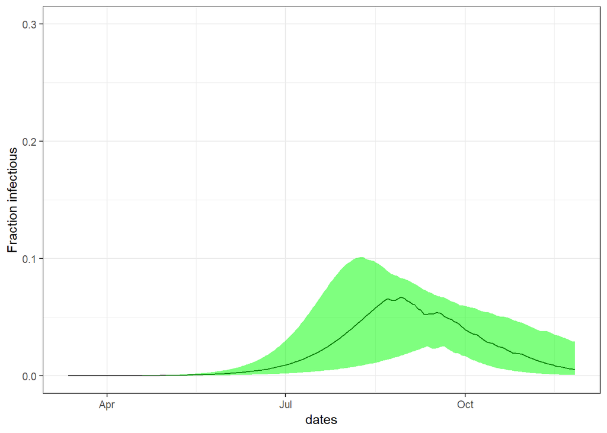

**Figure 3a**: Infections over time for high-level social distancing

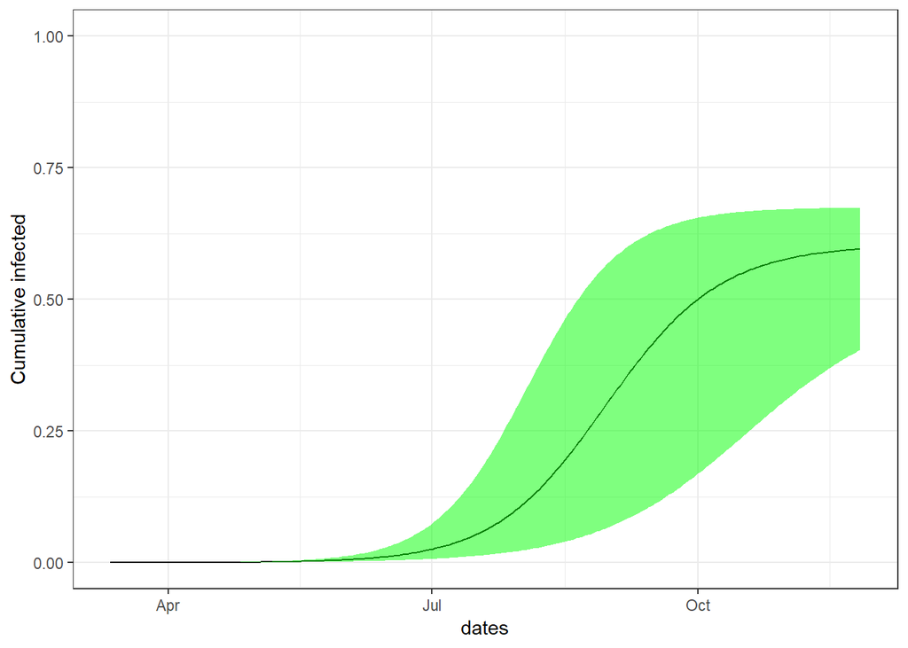

**Figure 3b**: Cumulative infections over time for high-level social distancing

## Comparisons and the early phase

Here we show three social distancing scenarios on the same plot for comparison, and we show the early rise. In most of the above plots, it looks like there are no cases in the first few months, but this is misleading. It’s not that there are no cases, it’s just that the numbers grow so high later that we can’t see the rises in the early phase unless we zoom in on that time period.

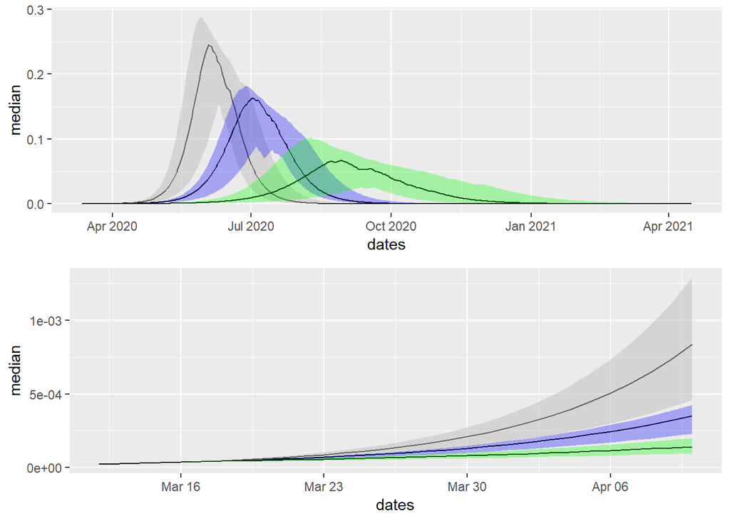

## Scenario 4.1: Strong Broad Social distancing limited to 200 days

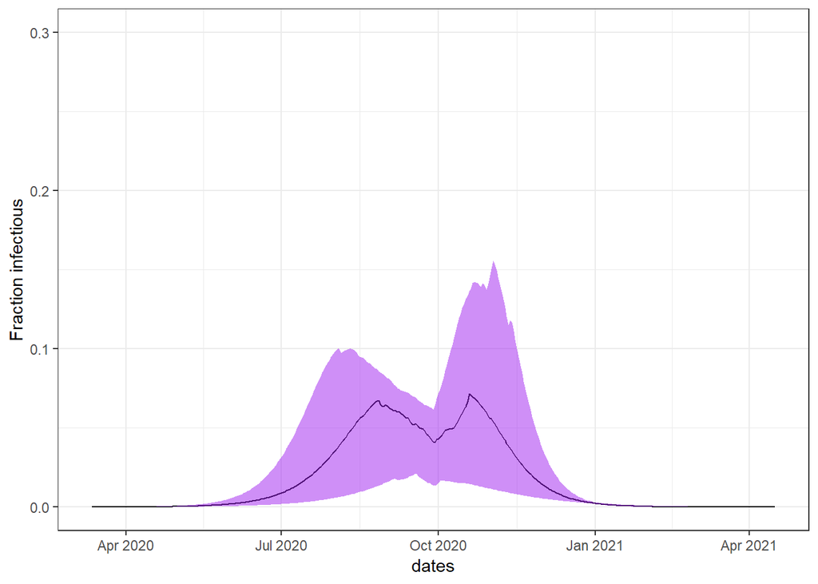

**Figure 4.1a**: Infections over time for 200 days of high-level social distancing

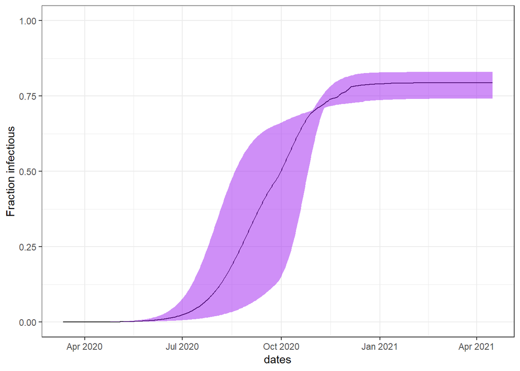

**Figure 4.1b**: Cumulative infections over time for 200 days of high-level social distancing

## Scenario 4.2: Strong Broad Social distancing limited to 100 days

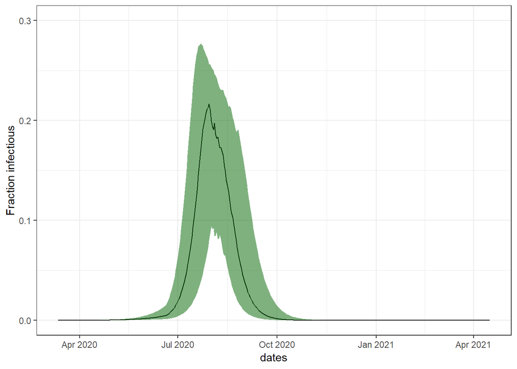

**Figure 4.2a**: Infections over time for 100 days of high-level social distancing

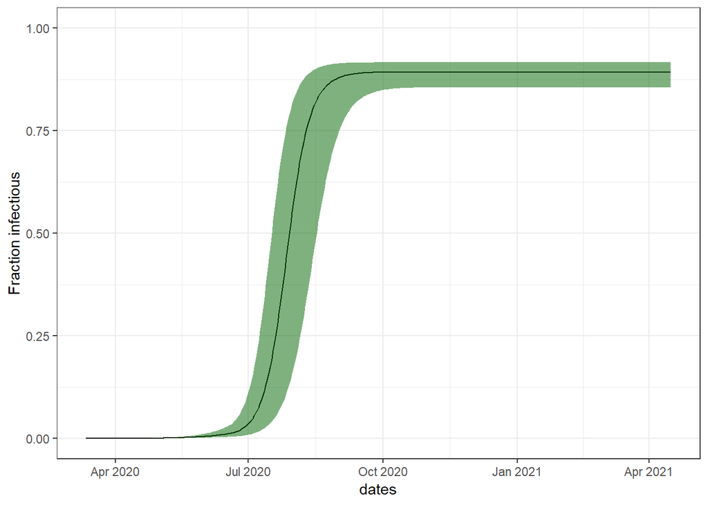

**Figure 4.2b**: Cumulative infections over time for 100 days of high-level social distancing

## Scenario 5c1: Slow 45-day social distancing

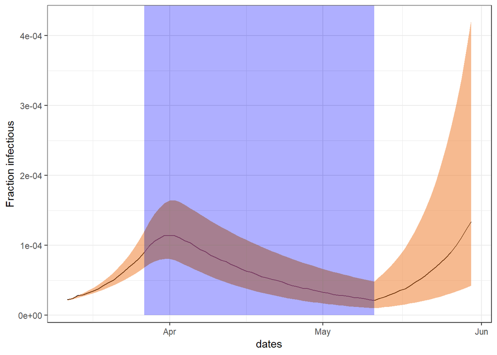

**Figure 5c1a**: Infections over time in the first 80 days for slow 45-day social distancing

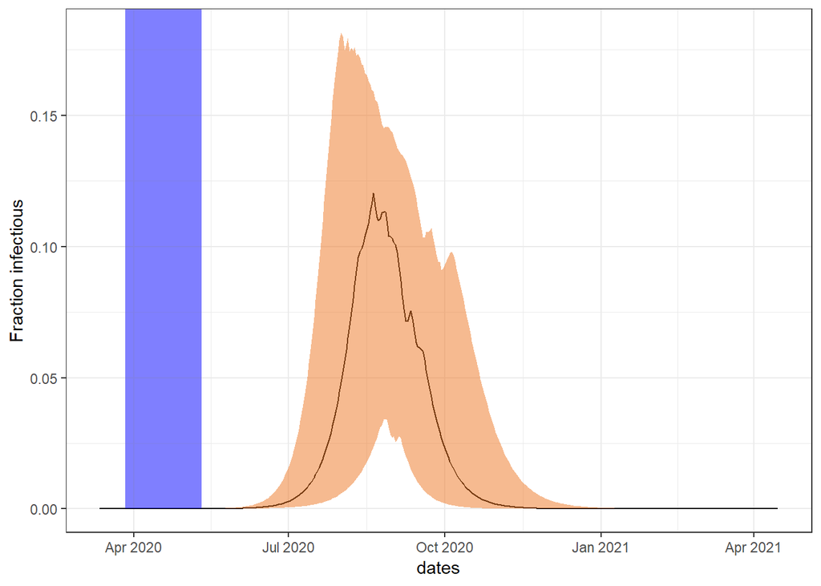

**Figure 5c1b**: Infections over time for slow 45-day social distancing in the longer term

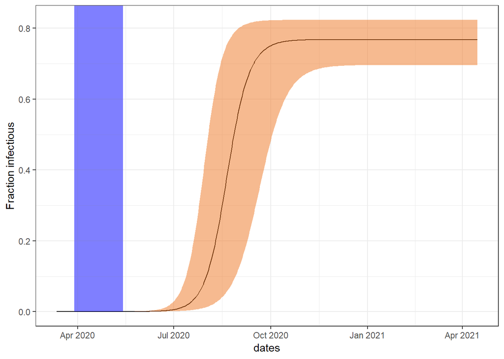

**Figure 5c1c**: Cumulative infections over time for slow 45-day social distancing in the longer term

## Scenario 5c2: Slow then very strong social distancing

Note: this scenario results in a peak of around 1,100 infections.

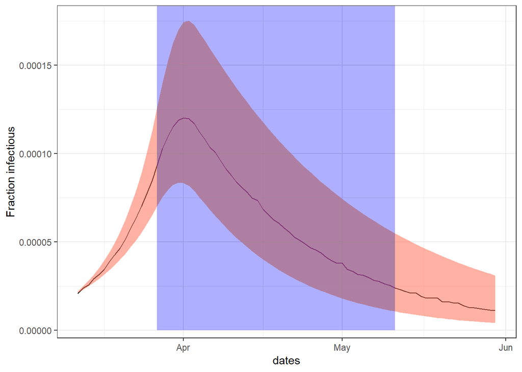

**Figure 5c2a**: Infections over time for slow then very strong social distancing in the first 80 days

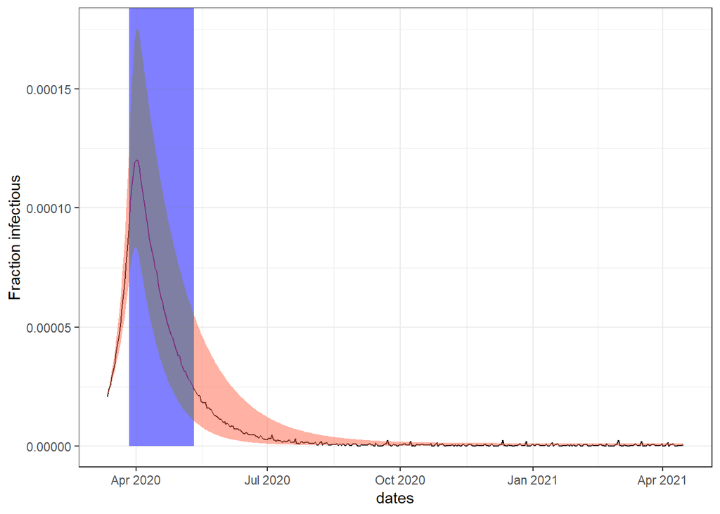

**Figure 5c2b**: Infections over time for slow then very strong social distancing in the longer term

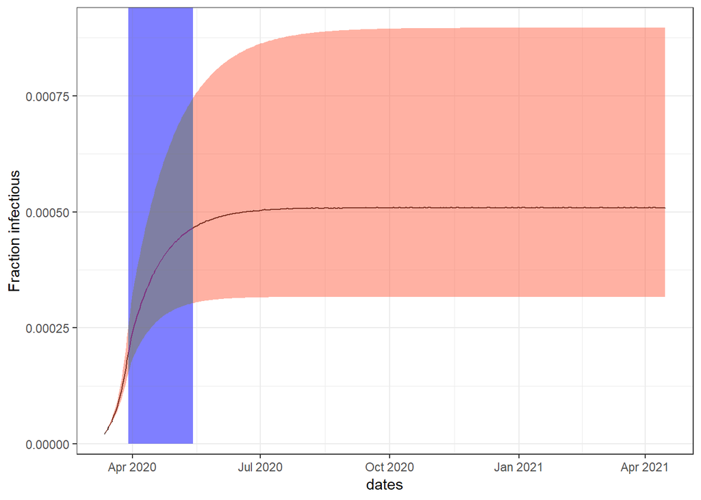

**Figure 5c2c**: Cumulative infections over time for slow then very strong social distancing in the longer term

Note: Scenario 5 “Planking” the curve or “supression” options have been excluded as they produce uncertain or unrealistic results. Scenario 6 on smaller population is excluded. To see these scenarios, go to the main model page.

# Data Summary and Download

## Summary of Assumptions and Results

[output not shown]

*Infection considered stopped when monthly infection falls below 100.  
✝Scenario 5c2 is a outbreak prevented scenario where infection never reaches population saturation.

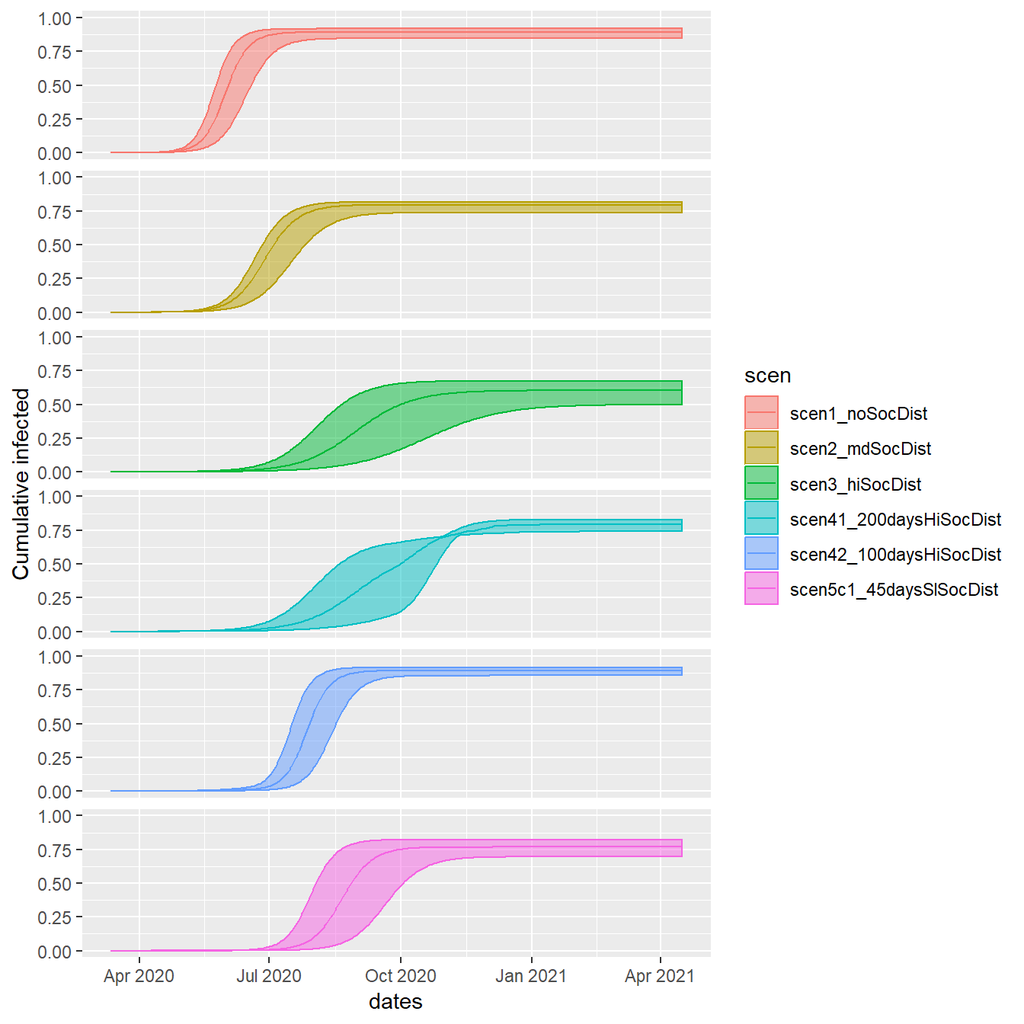

**Figure 6**: Cumulative infections over time for all scenarios (excl. scen5c2_slHiSocDist)

## Download Daily Data

**Download data export of cumulative infection by day for all scenarios: covid19_all_scen_daily.xlsx**

## Download Summary Data

**Download data export of cumulative and new infection by month for all scenarios: covid19_all_scen_monthly.xlsx**